# Tarea 5 Inferencia Estadística

Hairo Ulises Miranda Belmonte

6 de Noviembre de 2018

```r
library("knitr", lib.loc="~/R/win-library/3.3")
library("ggplot2", lib.loc="~/R/win-library/3.3")
```

## EJERCICIO 6

3. Determine mú de MV númericamente para el caso de que la media muestral sea 3.2

```r
mt <- .0001 # incrementos
m0 <- 0 # valor inicial
y <- numeric(1000) #número de simulaciones
xbarra <- 3.2 # media muestral
# Forma iterativa ( recursiva)
for(i in 1:1000){
y[i] <- xbarra - xbarra*exp(-(m0+mt))
m0 <- y[i]
} # end for
```

El estimador de maxima verosimilitud tiene unvalor de:

```r
print(kable(
  cbind('Estimador MV'=c('Mu estimado'= mean(y)))))
```

```
##
##
##                Estimador MV
## ------------  -------------
## Mu estimado        3.024529
```

## EJERCICIOS DIAPOSITIVAS 145

Diapositiva 145, inclusión a la variabilidad

Ejemplo: En una rama de la industria alimentaria, se realizan en forma rutinaria mediciones del contenido de calcio en comida para animales (mascotas). El metodo estandar utiliza precipitacion de oxalato de calcio seguida de tritanio; es una tecnica que consume tiempo. Los resultados de 118 muestras (Heckman 1960), se dan en el archivo calcio.txt (columna 1). Ahora, con lo que hemos discutido hasta aqu, que podemos decir a partir del comportamiento de estos valores muestrales?

Tomando los datos

```r
calcio <- read.delim("C:/Users/h_air/Desktop/Clase 21-20181027/calcio.txt")
```

Para iniciar, observaremos la distribución empirica contra una distribución normal teoríca. Para esto, utilizamos un qqplot.

```r
# # # # # # # # # # # # # # # # # # # # # # # #  # #
# Función : qqplot.data
# Gráfica qq-plot
#
# Input: Datos
# Outpu: QQ-PLOT gráfica
# # # # # # # # # # # # # #  # # # # # # # # # # # #
#qqplot

qqplot.data <- function (vec) # función qqplot
  {
  y <- quantile(vec[!is.na(vec)], c(0.25, 0.75))
  x <- qnorm(c(0.25, 0.75))
  slope <- diff(y)/diff(x)
  int <- y[1L] - slope * x[1L]
  d <- data.frame(resids = vec)
  ggplot(d, aes(sample = resids)) + stat_qq() + geom_abline(slope = slope, intercept = int)
} # end qqplot
```

Medición de contenido de calcio en comida de mascotas con el método estándar el cual utiliza precipitacion de oxalato de calcio seguida de tritanio.

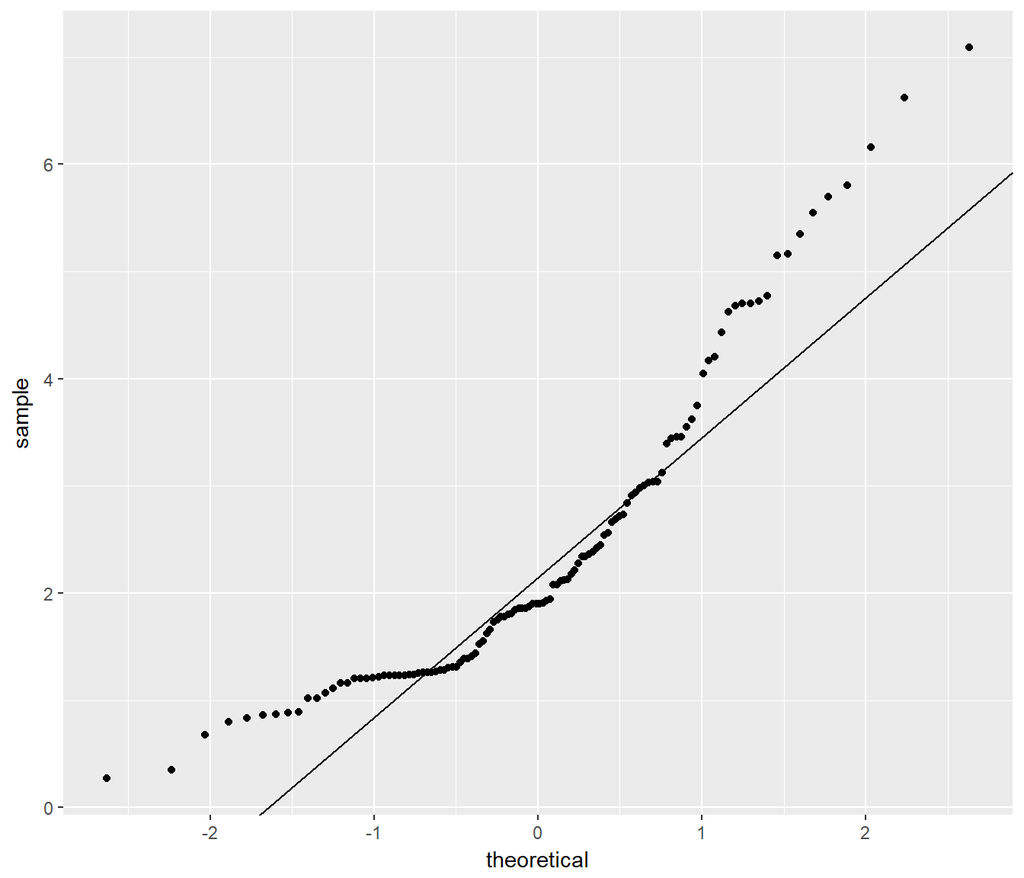

```r
qqplot.data(calcio$oxalate)
```

Como se observa en la gráfica, la distribución muestral respecto a una teorica normal, tiene una distribución sesgada a la derecha (izquierda para quien observa), con algunos valores a tipicos, y colas pesadas. Por ultimo, la distribución empirica no se aproxima a una normal en el centro de su distribución.

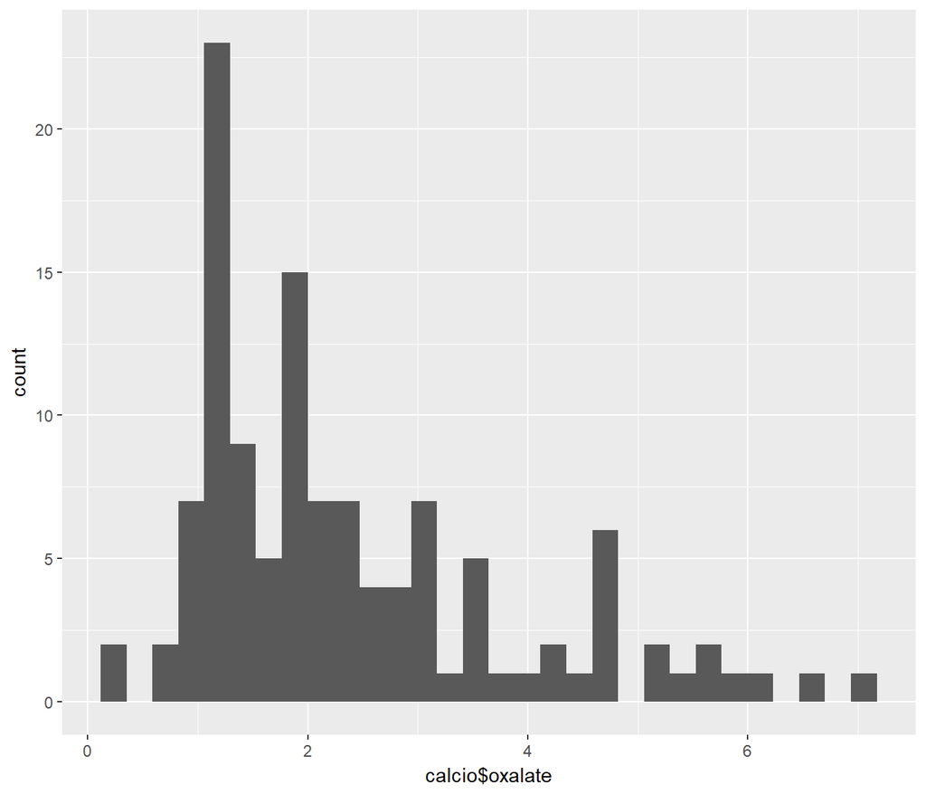

```r
# histograma de la distribución empirica
qplot(calcio$oxalate,
      geom="histogram")
```

Así como se comento con el qqplot, la distribución empirica presenta sesgo, colas pesadas y, valores atipicos. Lo anterior se puede apreciar mejor con el histograma.

También, se realiza un boxplot.

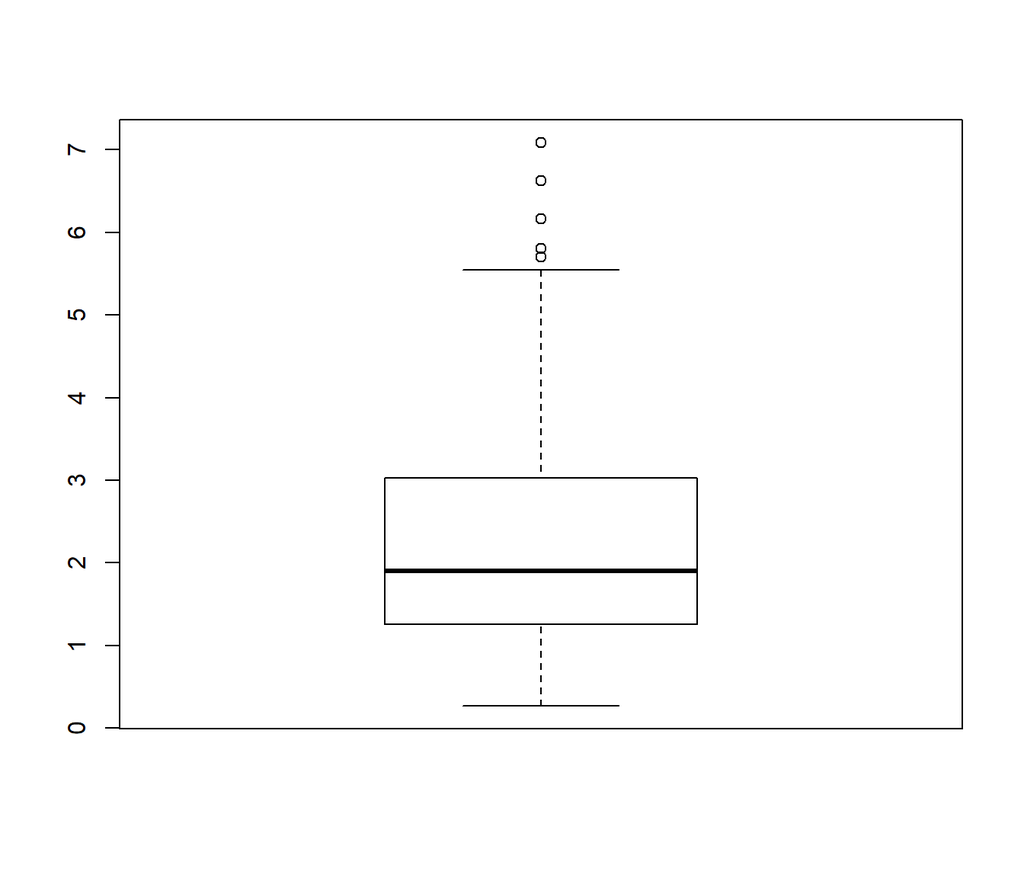

```r
boxplot(calcio$oxalate)
```

El boxplot de la distribución empirica, es decir, los datos sobre el método estándar, argumenta lo anterior dicho sobre los valores a tipicos. Tambien se ve de manera marcada el sesgo a la derecha (izquiera para quien ve), y como su mediana se tira a la derecha

En las notas se indica que posiblemente la variable aleatoria sea una log normal. Utilizando la serie con logaritmos veremos si la distribución muesrral en logaritmos se distribuye como una normal.

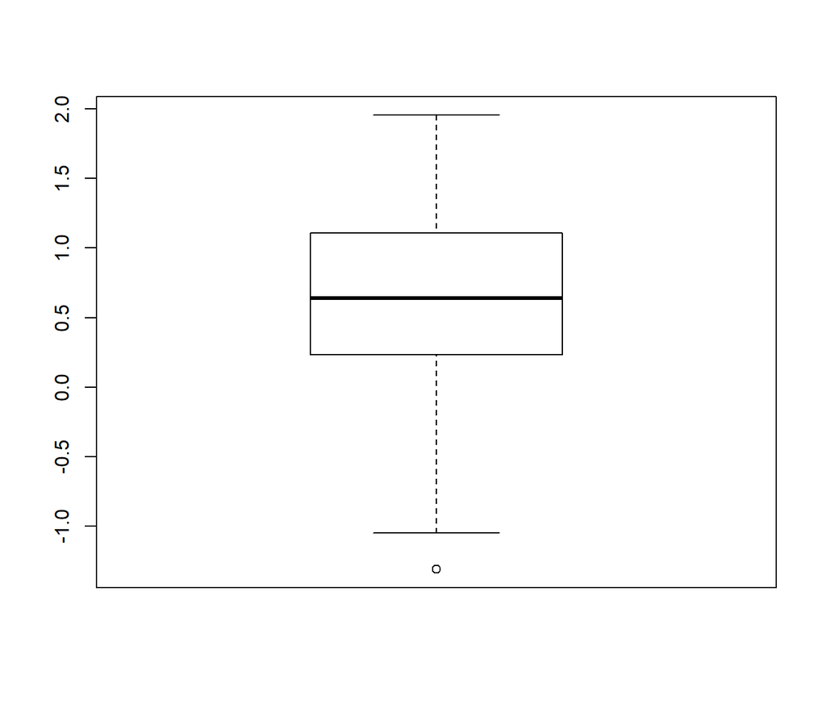

```r
boxplot(calcio$ln.oxalate.)
```

Se aprecia una mediana un poco a la izquierda, como la distribución se jala o se carga para el lado opuesto al no tener logaritmos,y por último, un valor a tipico perdido en la distribución.

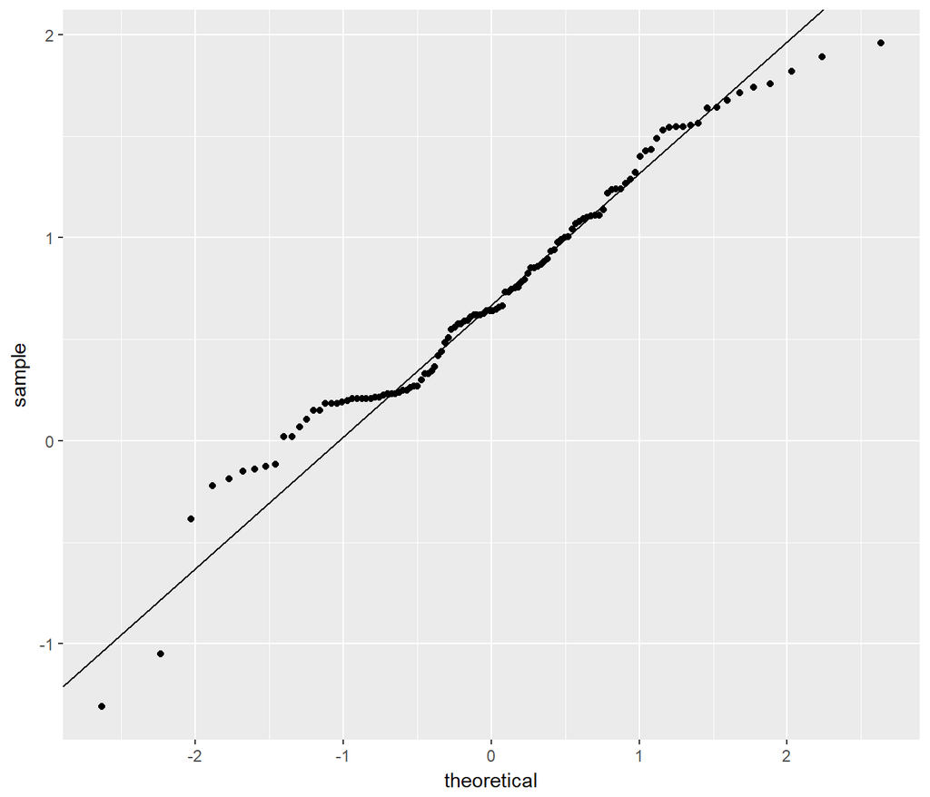

```r
qqplot.data(calcio$ln.oxalate)
```

Lo ya mencionado, se puede ver mejor con el qqplot. Los valores a tipicos en una de sus colas, y un poco de sesgo hacia el lado opuesto preevio de aplicar logaritmos. Es importante observar como el logaritmo de la muestra se distribuye como una normal.

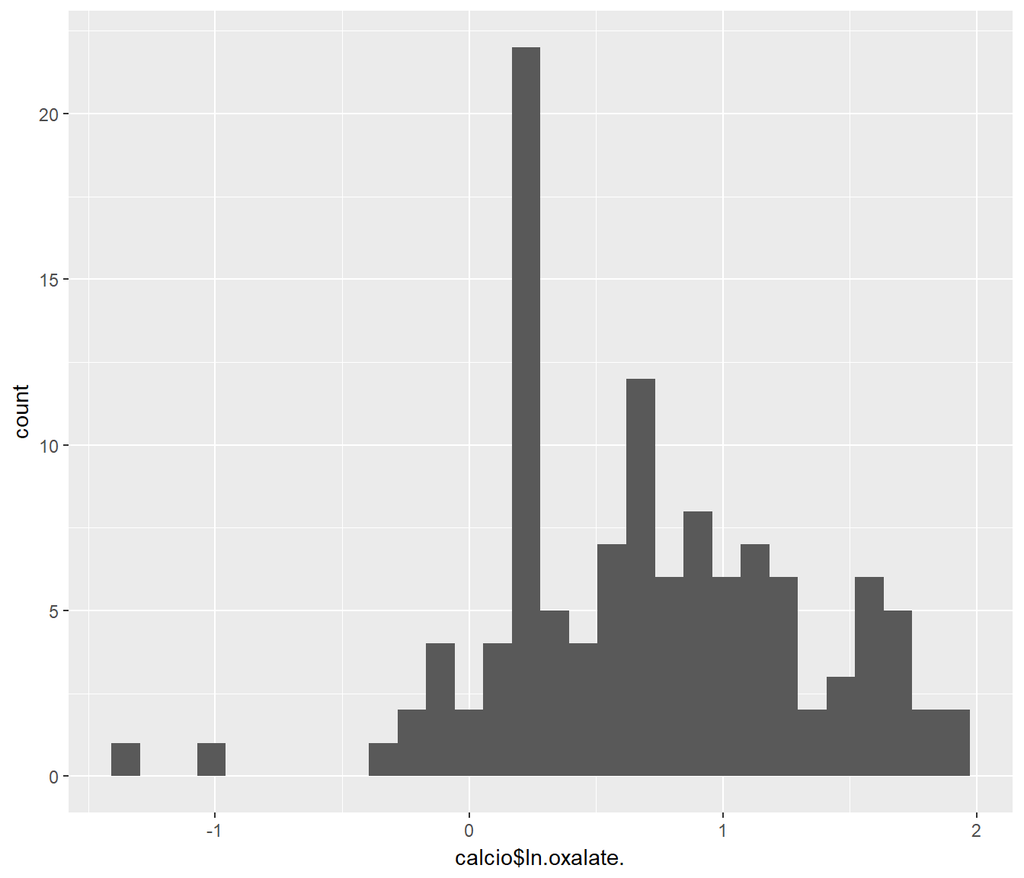

```r
qplot(calcio$ln.oxalate.,
      geom="histogram")
```

El histograma muestra de mejor manera lo descito con el qq plot. Note que la cola de uno de los lados es más pesada de lo que se veía con el qqplot.

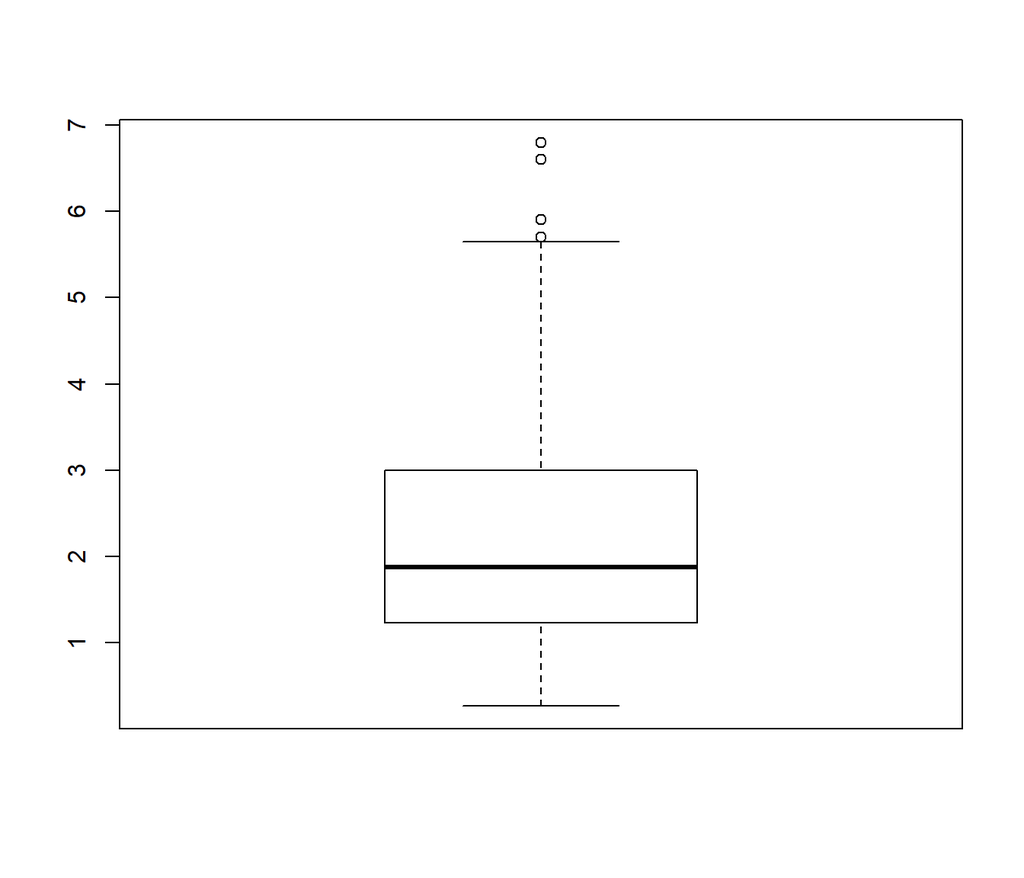

```r
boxplot(calcio$flame)
```

Se observan datoa a tipico en el derecho de la distribución (cola), y unamediana cargada hacia el lado izquierdo

En conclusión la muestra sin logaritmos se distribuye como una lognnormal, pero la muestra con logaritmos es una normal.

## EJERCICIOS DIAPOSITIVAS 179

IC PARA CALCIO PARA LOS DATOS DE CALCIO

```r
#valor medio del calcio
muEst<- mean(calcio$oxalate)
z <- 1.96 # z- valor
a <- .05 # Nivel de insignificanca
n <- 118
s <- sd(calcio$oxalate) # Des. Estandar

ICupper <- muEst + z*(s/sqrt(n)) # IC superior
IClower <- muEst - z*(s/sqrt(n)) # IC inferior
IC <- c(IClower, ICupper) # Intervalos de Confianza

# library("knitr", lib.loc="~/R/win-library/3.3") Install

print(kable(
  cbind('Intervalos de confianza'=c('LOWER'=IC[1], 'UPPER'=IC[2]))))
```

```
##
##
##          Intervalos de confianza
## ------  ------------------------
## LOWER                   2.125530
## UPPER                   2.649555
```

Considerando los logaritmos y consideramos pivote que sigue una t de student.

```r
LogMuEst<- mean(calcio$ln.oxalate) # media del logaritmo de la muestra
```

```r
t117 <- 1.96 # t- valor
a <- .05 # ni vel de insignificancia estadística
n <- 118
sLog <- sd(calcio$ln.oxalate) # Des. Estandar de los logaritmmos de la muestra

LogICupper <- LogMuEst + t117*(sLog/sqrt(n)) # IC superior
LogIClower <- LogMuEst - t117*(sLog/sqrt(n)) # IC inferior
LogIC <- c(LogIClower, LogICupper) # intervalos de confianza
ErrorEstimacion <- t117*(sLog/sqrt(n)) # error de estimación

print(kable(
  cbind('IC (log muestra)'=c('LOWER'=LogIC[1],
                                                  'UPPER'=LogIC[2],
                                                  'Error de estimación'=ErrorEstimacion))))
```

```
##
##
##                        IC (log muestra)
## --------------------  -----------------
## LOWER                         0.5894296
## UPPER                         0.8058099
## Error de estimación           0.1081901
```

Tomando transformación inversa a los logaritmos del intervalo de confianza

```r
InvLogIC <- c(exp(LogIClower), exp(LogICupper)) # intervalos con exponencial

print(kable(
  cbind('IC (exponencial log muestra)'=c('LOWER'=InvLogIC[1],
                                                  'UPPER'=InvLogIC[2]))))
```

```
##
##
##          IC (exponencial log muestra)
## ------  -----------------------------
## LOWER                        1.802960
## UPPER                        2.238509
```

En este ultimo intervalo deberamos notar que la relacion entre la media de la variable original y la de su transformacion logartmica esta afectada por una constante que aqu no aparece. Recuerda la relacion entre medias y varianzas que hemos establecido al nal del captulo 3, para la Normal y Lognormal. Trata de incorporar esta informacion para entender mejor la diferencia numerica entre estos intervalos.

sabemos que los momentos de una normal y lognormal son distintos, ya que si una variable se distribuye como una lognormal, su generadora de momentos no existe. Pero sabemos como es la generadora de una normal, de esta forma la variable que se distribuye como una lognormal al sacarle la esperanza es como si plantearas la generadora pero con una e a la xt, sin t. lo cual el esperados es la generadora de momentos de una normal pero evaluando t en el momento que se quiera de la log normal.

Ahora comparamos las muestras del archivo txt. Calculamos la diferencia entre medias de los dos métodos distintos. El método con oxalte será el método estándar, el Flame el alternativo.

```r
meanA<-mean(calcio$oxalate)- mean(calcio$flame) # Diferencia entre medias
varA <- var(calcio$oxalate)/var(calcio$flame) # Cociente de variación

print(kable(
  cbind('Dif. entre dos Poblaciones'=c('Diff. Medias'=meanA,
                                                              'Cociente Varianzas'=varA))))
```

```
##
##
##                       Dif. entre dos Poblaciones
## -------------------  ---------------------------
## Diff. Medias                           0.0355932
## Cociente Varianzas                     1.0430312
```

Se oserva que el estadístico de la diferencia de medias entre poblaciones, es relativamente pequeño. Lo cual, ya era de esperarse dado a la descripción de los datos (i.e, vienen de poblacioneslo más homogeneas posibles). Entonces, como se pretendia que la muestras fueran lo controladas pero independientes, se toma un críterio de variabilidad. El cociente entre la varianza de la muestra estandar y la alternativa es ligeramente mayor a uno. Sin embargo, decir que la muestra de la población estandar es más variable seria muy precipitado.

A continuación, se construye un intervalo de confianza para la diferencia de medias

```r
DSA<- sqrt(varA)
UPPER <- mean(calcio$oxalate)-mean(calcio$flame)+1.64*DSA
LOWER <- mean(calcio$oxalate)-mean(calcio$flame)-1.64*DSA

print(kable(
  cbind('Dif. entre dos Poblaciones IC'=c('IC Lower'=UPPER,
                                             'IC upper'=LOWER))))
```

```
##
##
##             Dif. entre dos Poblaciones IC
## ---------  ------------------------------
## IC Lower                         1.710507
## IC upper                        -1.639321
```

Para seguir jugando un poco con los datos, se simula la proporción de veces que el intervalo de confianza contiene al valor de la hipótesis sobre la Nula. Recordemos que dicho valor es fijo,o dado, y son los intervalos de confianza la que es una variable aleatoria, la cual en cada simmulación estarán cambiando.

```r
outsideCI <- numeric(1000)  # almacenando proporción de veces que IC no contiene}
# el valor de la hipótesis nula

set.seed(1) # fijando semlla
# Ho: X = 0 vs Ha: X otra cosa
for (i in 1:1000){
  xmean <- rnorm(118, mean(calcio$oxalate), sd(calcio$oxalate))
  ymean <- rnorm(118, mean(calcio$flame), sd(calcio$flame))
  CI.lower <- (mean(xmean)-mean(ymean)) - qt(0.975, n-1)*DSA
  CI.upper <- (mean(xmean)-mean(ymean)) + qt(0.975, n-1)*DSA
  outsideCI[i] <- ifelse(0 < CI.lower | 0 < CI.upper, 1, 0)
} # en for

mean(outsideCI) # proporcion de la veces que mi intervalo
```

```
## [1] 1
```

```r
# no cubre el valor de la Ho: 0
print(kable(
  cbind('prop.veces IC contiene Ho'=c('100%(1-alpha)'=mean(outsideCI)*100))))
```

```
##
##
##                  prop.veces IC contiene Ho
## --------------  --------------------------
## 100%(1-alpha)                          100
```

A continuación, realizamos el mismo ejercicio pero utilizando el p-valor

```r
set.seed(1)
reps <- 100000  # número de simulaciones
## Aproximación de los p valores

pvalues <- numeric(reps)
for (i in 1:1000) {
  xmean <- rnorm(118, mean(calcio$oxalate), sd(calcio$oxalate))
  ymean <- rnorm(118, mean(calcio$flame), sd(calcio$flame))
  t.stat <- ((mean(xmean)-mean(ymean)+(0))/DSA)
  pvalues[i] <- 2*(1 - pt(abs(t.stat), n-2))
  # Forma alternativa: pvalues[i] <- t.test(x, mu = mu0)$p.value
} # end for

mean(pvalues < 0.05) # Con un alpha de 0.05
```

```
## [1] 0.99
```

```r
print(kable(
  cbind('p-valor'=c('100%(1-alpha)'=mean(pvalues < 0.05)*100))))
```

```
##
##
##                  p-valor
## --------------  --------
## 100%(1-alpha)         99
```

## EJERCICIOS BOOTSTRAP

Se pretende realizar un ejercicios computacional y estadístico utilizando bootstrap. Cuyo fin es estimar los errores estandar de algun estadístico. El caso de Intervalos de confienza con método bootstrap queda pediente parallel el siguiente tema.

Se utiliza los datos del archivo txt.

```r
median(calcio$oxalate)  # Estadístico seleccionado Mediana
```

```
## [1] 1.9
```

```r
tboot <- numeric(1000) # Almacena la simulación
for(i in 1:1000){ # Mil simulaciones
  xstar <- sample(calcio$oxalate,10, TRUE) # Algoritmo, tomar muestra con repetición de la función de distribución empirica
  #equivale a tomar un punto aleatorio en los datos originales.
    tboot[i] <- median(xstar)
} # end for

me <- median(tboot) #  mediana simulada por boostrap
se <- sqrt(var(tboot)) # Error estandar de la mediana



print(kable(
  cbind('Error estandar'=c('Mediana'=median(tboot),'Error estandar'=se))))
```

```
##
##
##                   Error estandar
## ---------------  ---------------
## Mediana                1.9250000
## Error estandar         0.4864468
```

Se observa como su media se aproxima a la verdadera cuando se utiliza em método de bootstra.